# Practical_machine_learning_assignment

Hang_YU

November 23, 2016

## Getting and Cleaning Data

Load dependency libraries

```r
library(caret)
library(doParallel)
library(randomForest)
```

Load training data and testing data

```r
pml_training <- read.csv("~/pml_training.csv",na.strings = c("NA","#DIV/0!",""))
pml_testing <- read.csv("~/pml_testing.csv",na.strings = c("NA","#DIV/0!",""))
```

Since both training set and testing set contain columns with NA, we remove those columns.

```r
NA_feature <- apply(pml_training, 2, function(x) any(is.na(x)))
training <- pml_training[,!NA_feature]
testing <- pml_testing[,!NA_feature]
```

```r
dim(training)
```

```
## [1] 19622    60
```

## Data Partition

The training set is splitted to one sub training set and one validation set for building the model. Besides, we do the first dimension reducing by removing the columns that are only for information reference such as sequence number.

```r
InTrain <- createDataPartition(training$classe,p=0.7,list=FALSE)
trainSet <- training[InTrain,-c(1:5)]
validSet <- training[-InTrain,-c(1:5)]
dim(trainSet)
```

```
## [1] 13737    55
```

## Dimension Reduction

In order to reduce dimension, we check if there exists any zero-variance predictor

```r
nzv <- nearZeroVar(trainSet,saveMetrics = TRUE)
nzv
```

```
##                      freqRatio percentUnique zeroVar   nzv
## new_window           47.540636    0.01455922   FALSE  TRUE
## num_window            1.035714    6.24590522   FALSE FALSE
## roll_belt             1.033951    8.17500182   FALSE FALSE
## pitch_belt            1.090909   12.28798136   FALSE FALSE
## yaw_belt              1.051282   13.08145883   FALSE FALSE
## total_accel_belt      1.052319    0.21110868   FALSE FALSE
## gyros_belt_x          1.050209    0.95362889   FALSE FALSE
## gyros_belt_y          1.119793    0.48045425   FALSE FALSE
## gyros_belt_z          1.105616    1.20841523   FALSE FALSE
## accel_belt_x          1.027726    1.15745796   FALSE FALSE
## accel_belt_y          1.054895    0.99730654   FALSE FALSE
## accel_belt_z          1.079288    2.09652763   FALSE FALSE
## magnet_belt_x         1.091633    2.19844216   FALSE FALSE
## magnet_belt_y         1.119101    2.10380724   FALSE FALSE
## magnet_belt_z         1.044910    3.20302832   FALSE FALSE
## roll_arm             52.200000   17.58025770   FALSE FALSE
## pitch_arm            83.928571   20.32467060   FALSE FALSE
## yaw_arm              33.084507   19.01434083   FALSE FALSE
## total_accel_arm       1.039370    0.47317464   FALSE FALSE
## gyros_arm_x           1.005479    4.58615418   FALSE FALSE
## gyros_arm_y           1.354396    2.66433719   FALSE FALSE
## gyros_arm_z           1.069892    1.70342870   FALSE FALSE
## accel_arm_x           1.067797    5.56890151   FALSE FALSE
## accel_arm_y           1.178082    3.81451554   FALSE FALSE
## accel_arm_z           1.055556    5.57618112   FALSE FALSE
## magnet_arm_x          1.047619    9.62364417   FALSE FALSE
## magnet_arm_y          1.263158    6.21678678   FALSE FALSE
## magnet_arm_z          1.112500    9.12135110   FALSE FALSE
## roll_dumbbell         1.019608   86.70015287   FALSE FALSE
## pitch_dumbbell        2.107843   84.40707578   FALSE FALSE
## yaw_dumbbell          1.159091   85.93579384   FALSE FALSE
## total_accel_dumbbell  1.058333    0.29846400   FALSE FALSE
## gyros_dumbbell_x      1.004662    1.68158987   FALSE FALSE
## gyros_dumbbell_y      1.223881    1.93637621   FALSE FALSE
## gyros_dumbbell_z      1.097015    1.43408313   FALSE FALSE
## accel_dumbbell_x      1.035294    3.00647885   FALSE FALSE
## accel_dumbbell_y      1.063584    3.31950207   FALSE FALSE
## accel_dumbbell_z      1.144578    2.89728471   FALSE FALSE
## magnet_dumbbell_x     1.039370    7.87653782   FALSE FALSE
## magnet_dumbbell_y     1.367521    5.96928005   FALSE FALSE
## magnet_dumbbell_z     1.007519    4.83366092   FALSE FALSE
## roll_forearm         12.313901   13.75846255   FALSE FALSE
## pitch_forearm        66.975610   19.01434083   FALSE FALSE
## yaw_forearm          15.685714   12.80483366   FALSE FALSE
## total_accel_forearm   1.129220    0.49501347   FALSE FALSE
## gyros_forearm_x       1.016173    2.12564607   FALSE FALSE
## gyros_forearm_y       1.010949    5.25587828   FALSE FALSE
## gyros_forearm_z       1.069971    2.13292568   FALSE FALSE
## accel_forearm_x       1.000000    5.67809565   FALSE FALSE
## accel_forearm_y       1.104478    7.12673801   FALSE FALSE
## accel_forearm_z       1.045455    4.04746306   FALSE FALSE
## magnet_forearm_x      1.037736   10.69374682   FALSE FALSE
## magnet_forearm_y      1.186441   13.25616947   FALSE FALSE
## magnet_forearm_z      1.000000   11.80752712   FALSE FALSE
## classe                1.469526    0.03639805   FALSE FALSE
```

Fairly there is no much to do with the result of nzv. They we run a fast random forest and test variable importance for dimension reducing.

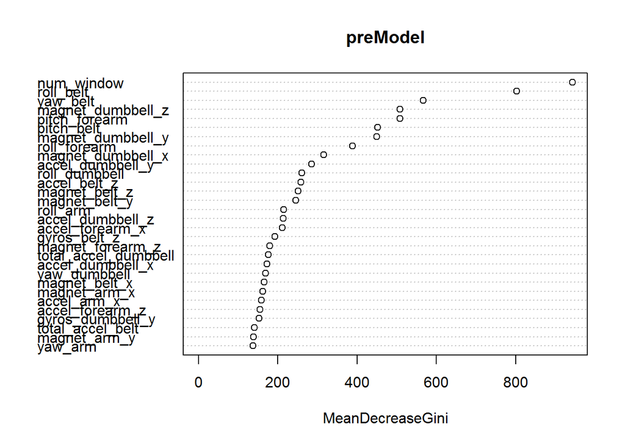

```r
registerDoParallel()
preModel <- randomForest(classe~.,data=trainSet)
varImpPlot(preModel)
```

```r
trainSet <- trainSet[,c("num_window","roll_belt","yaw_belt","pitch_forearm","magnet_dumbbell_z","pitch_belt","magnet_dumbbell_y","accel_dumbbell_y","classe")]
validSet <- validSet[,c("num_window","roll_belt","yaw_belt","pitch_forearm","magnet_dumbbell_z","pitch_belt","magnet_dumbbell_y","accel_dumbbell_y","classe")]
dim(trainSet)
```

```
## [1] 13737     9
```

## Model Training and Testing

We use caret package to train and test the model. Random forest with cross validation (10 k-fold) is used here.

```r
registerDoParallel()
modelFit <- train(classe~.,data=trainSet,method="rf",trControl=trainControl(method = "cv"))
pred <- predict(modelFit,newdata=validSet)
confusionMatrix(pred,validSet$classe)
```

```
## $positive
## NULL
##
## $table
##           Reference
## Prediction    A    B    C    D    E
##          A 1674    2    0    0    0
##          B    0 1134    0    0    2
##          C    0    2 1026    1    1
##          D    0    1    0  962    0
##          E    0    0    0    1 1079
##
## $overall
##       Accuracy          Kappa  AccuracyLower  AccuracyUpper   AccuracyNull
##      0.9983008      0.9978506      0.9968773      0.9991849      0.2844520
## AccuracyPValue  McnemarPValue
##      0.0000000            NaN
##
## $byClass
##          Sensitivity Specificity Pos Pred Value Neg Pred Value Precision
## Class: A   1.0000000   0.9995251      0.9988067      1.0000000 0.9988067
## Class: B   0.9956102   0.9995786      0.9982394      0.9989471 0.9982394
## Class: C   1.0000000   0.9991768      0.9961165      1.0000000 0.9961165
## Class: D   0.9979253   0.9997968      0.9989616      0.9995937 0.9989616
## Class: E   0.9972274   0.9997918      0.9990741      0.9993757 0.9990741
##             Recall        F1 Prevalence Detection Rate
## Class: A 1.0000000 0.9994030  0.2844520      0.2844520
## Class: B 0.9956102 0.9969231  0.1935429      0.1926933
## Class: C 1.0000000 0.9980545  0.1743415      0.1743415
## Class: D 0.9979253 0.9984432  0.1638063      0.1634664
## Class: E 0.9972274 0.9981499  0.1838573      0.1833475
##          Detection Prevalence Balanced Accuracy
## Class: A            0.2847918         0.9997625
## Class: B            0.1930331         0.9975944
## Class: C            0.1750212         0.9995884
## Class: D            0.1636364         0.9988611
## Class: E            0.1835174         0.9985096
##
## $mode
## [1] "sens_spec"
##
## $dots
## list()
##
## attr(,"class")
## [1] "confusionMatrix"
```

From the results, the prediction accurary is 99.83%, which needs to no more predictors.

## Testing Set Prediction

Next, we use the random forest model to predict the testing set. As expected, the results are 100% correct.

```r
pred_test <- predict(modelFit,newdata=testing)
pred_test
```

```
##  [1] B A B A A E D B A A B C B A E E A B B B
## Levels: A B C D E
```